# Tratamiento de caudales: Sincronización

Rafael Navas -

Última actualización: 03 junio 2020

## Sumario

Esta sección muestra un control de calidad, sincronización y ajuste de los datos de caudal. Este proceso se hace para corregir cualquier posible desfase de las series temporales de caudal con respecto a la lluvia. Así como suavizar posibles errores en las magnitudes de los caudales observados.

```r
resumen = readRDS("~/R_projects/SWAT_calibration_ETmodis/resultados/ajustes_caudal_resumen.RDS")

kable(resumen, caption ="Resumen de ajuste y sincronización de caudales en el Santa Lucía") %>%
  kable_styling(c("striped", "bordered"))
```

Resumen de ajuste y sincronización de caudales en el Santa Lucía

|  | Paso de los Troncos | Paso Roldán | Fray Marcos | San Ramón | Paso Pache |
| --- | --- | --- | --- | --- | --- |
| lluvia media mensual (mm) | 104.30 | 107.10 | 103.40 | 104.70 | 104.90 |
| escurrimiento medio mensual (mm) | 22.30 | 47.40 | 30.50 | 50.40 | 32.70 |
| coef.esc (-) | 0.21 | 0.44 | 0.29 | 0.48 | 0.31 |
| ajuste (-) | 1.65 | 0.79 | 1.19 | 0.72 | 1.12 |
| lag (días) | 1.00 | 1.00 | 1.00 | 2.00 | 2.00 |

## Correlación cruzada de nivel horario

A continuación se muestra la correlación del nivel horario entre las tres estaciones de nivel. Los datos han sido descargados de la web de dinagua y se leen como datos brutos sin control de calidad, por lo que deben ser utilizados con precaución.

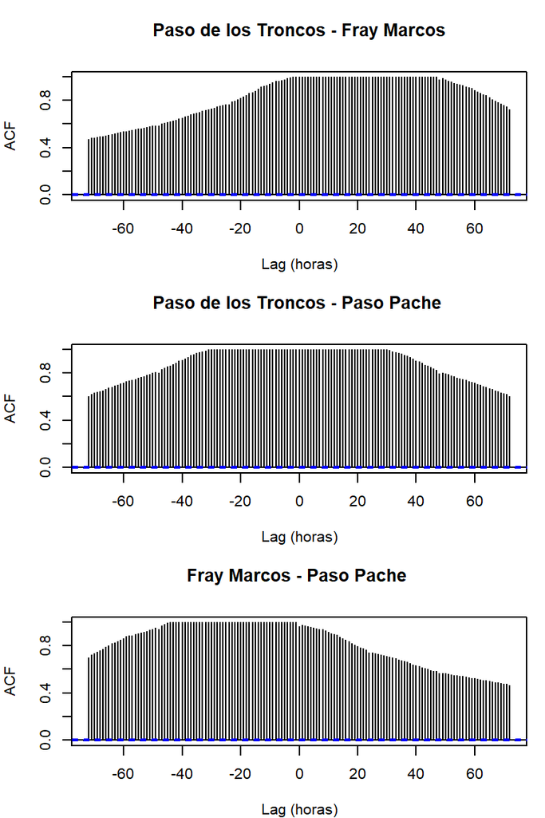

```r
# Data read
data41 = read.table("~/R_projects/SWAT_calibration_ETmodis/data/paso_pache.csv", sep=",", quote = "")
colnames(data41) = c("h","date")
data41$h = as.numeric(data41$h)
data41$date = substr(data41$date,3,18)
data41$date = as.POSIXct(data41$date, tz="", format=c("%Y-%m-%d %H:%M"))
data41 = data41[as.Date(data41$date)>=as.Date("2005-12-1"),]

data23 = read.table("~/R_projects/SWAT_calibration_ETmodis/data/paso_de_los_troncos.csv", sep=",", quote = "")
colnames(data23) = c("h","date")
data23$h = as.numeric(data23$h)
data23$date = substr(data23$date,3,18)
data23$date = as.POSIXct(data23$date, tz="", format=c("%Y-%m-%d %H:%M"))
data23 = data41[as.Date(data23$date)>=as.Date("2005-12-1"),]

data36 = read.table("~/R_projects/SWAT_calibration_ETmodis/data/fray_marcos.csv", sep=",", quote = "")
colnames(data36) = c("h","date")
data36$h = as.numeric(data36$h)
data36$date = substr(data36$date,3,18)
data36$date = as.POSIXct(data36$date, tz="", format=c("%Y-%m-%d %H:%M"))
data36 = data36[as.Date(data36$date)>=as.Date("2005-12-1"),]

library(openair)
# Time average
h41 = timeAverage(data41, avg.time = "60 min", fill = FALSE, interval = "60 min",
                  statistic = "mean", start.date = "2005-01-01")
h23 = timeAverage(data23, avg.time = "60 min", fill = FALSE, interval = "60 min",
                  statistic = "mean", start.date = "2005-01-01")
h36 = timeAverage(data36, avg.time = "60 min", fill = FALSE, interval = "60 min",
                  statistic = "mean", start.date = "2005-01-01")

h = data.frame(h41 = h41$h, h23=h23$h, h36=h36$h)

par(mfrow=c(3,1), mar=c(4,4,4,1))
ccf(h$h23,
    h$h36,
    na.action=na.pass, lag.max=24*3,
    main = "Paso de los Troncos - Fray Marcos",
    xlab= "Lag (horas)")

ccf(h$h23,
    h$h41,
    na.action=na.pass, lag.max=24*3,
    main="Paso de los Troncos - Paso Pache ",
        xlab= "Lag (horas)")

ccf(h$h36,
    h$h41,
    na.action=na.pass, lag.max=24*3,
    main="Fray Marcos - Paso Pache ",
        xlab= "Lag (horas)")
```

## Correlación cruzada de caudal diario

A continuación se muestra la correlación cruzada del caudal diario entre las estaciones. Los datos han sido obtenidos del drive del grupo de trabajo del Santa Lucía, por consiguiente, los datos han sido manipulados y se desconoce cómo ha sido dicha manipulación.

La siguiente figura muestra que:

- Paso de los Troncos y Fray Marcos están sincronizados.
- Paso Pache está en desface con respecto a paso de los Troncos y a Fray Marcos

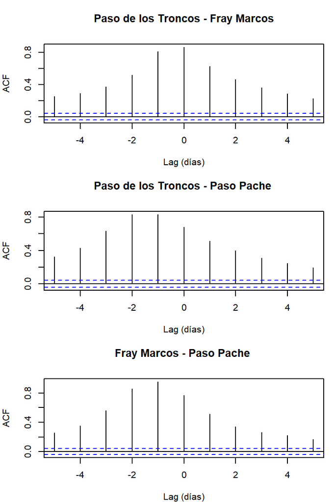

```r
library(zoo)
obs.data <- readRDS("~/R_projects/SWAT_calibration_ETmodis/data/obs.data.RDS")

par(mfrow=c(3,1), mar=c(4,4,4,1))
ccf(obs.data$q23,
    obs.data$q36,
    na.action=na.pass, lag.max=5,
    main = "Paso de los Troncos - Fray Marcos",
    xlab= "Lag (días)")

ccf(obs.data$q23,
    obs.data$q41,
    na.action=na.pass, lag.max=5,
    main="Paso de los Troncos - Paso Pache ",
    xlab= "Lag (días)")

ccf(obs.data$q36,
    obs.data$q41,
    na.action=na.pass, lag.max=5,
    main="Fray Marcos - Paso Pache ",
    xlab= "Lag (días)")
```

## Correlación Precipitación-Caudal

A continuación se muestra la correlación de la precipitación con el caudal diario. Cómo precipitación diaria se utiliza el promedio de la precipitación de las estaciones pluviométricas. Por otro lado, el caudal se utiliza la misma base de datos que la sección Correlación cruzada de caudal diario.

La siguiente figura muestra que:

- Paso de los troncos retrasa a la lluvia en 1 día.
- Fray Marcos está 1~2 días por detrás de la lluvia.
- Paso Pache retrasa a la lluvia en 2~3 días.

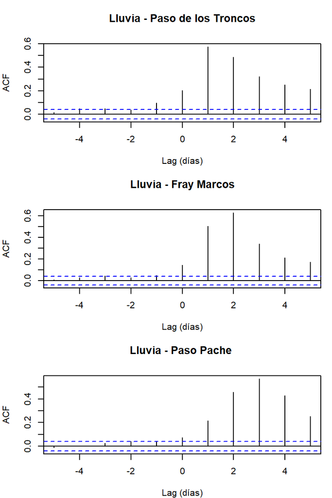

```r
t1 = min(index(obs.data))
t2 = max(index(obs.data))
p <- readRDS("~/R_projects/SWAT_calibration_ETmodis/data/precip_SL_1981_2016.RDS")
cc = p$date>= t1 & p$date<=t2
p = p[cc,-1]
p = apply(p,1, function(x){mean(x,na.rm = T)})

par(mfrow=c(3,1), mar=c(4,4,4,1))
ccf(as.vector(obs.data$q23),
    p,
    na.action=na.pass, lag.max=5,
    main = "Lluvia - Paso de los Troncos",
    xlab= "Lag (días)")

ccf(as.vector(obs.data$q36),
    p,
    na.action=na.pass, lag.max=5,
    main="Lluvia - Fray Marcos",
    xlab= "Lag (días)")

ccf(as.vector(obs.data$q41),
    p,
    na.action=na.pass, lag.max=5,
    main="Lluvia - Paso Pache ",
    xlab= "Lag (días)")
```

## Sincronización de caudales

Considerando lo mostrado en la sección Correlación Precipitación-Caudal se opta por adelantar los caudales de Paso de los Troncos y Fray Marcos en 1 día y Paso Pache en 2 días.

De esta manera quedan sincronizadas no sólo con la precipitación sino también con las otras estaciones de caudal.

A continuación se muestra la verificación de la sincronización realizada Lluvia - Caudal. Se observa que:

- Paso de los Troncos tiene la máxima correlación en fase con la lluvia. Lo que tiene sentido ya que es una cuenca chica.
- Fray Marcos y Paso Pache la máxima correlación se obtiene un día después de la lluvia. Este resultado parece correcto ya que el tiempo de concentración de dichas cuencas es considerablemente mayor a el de Paso de los Troncos.

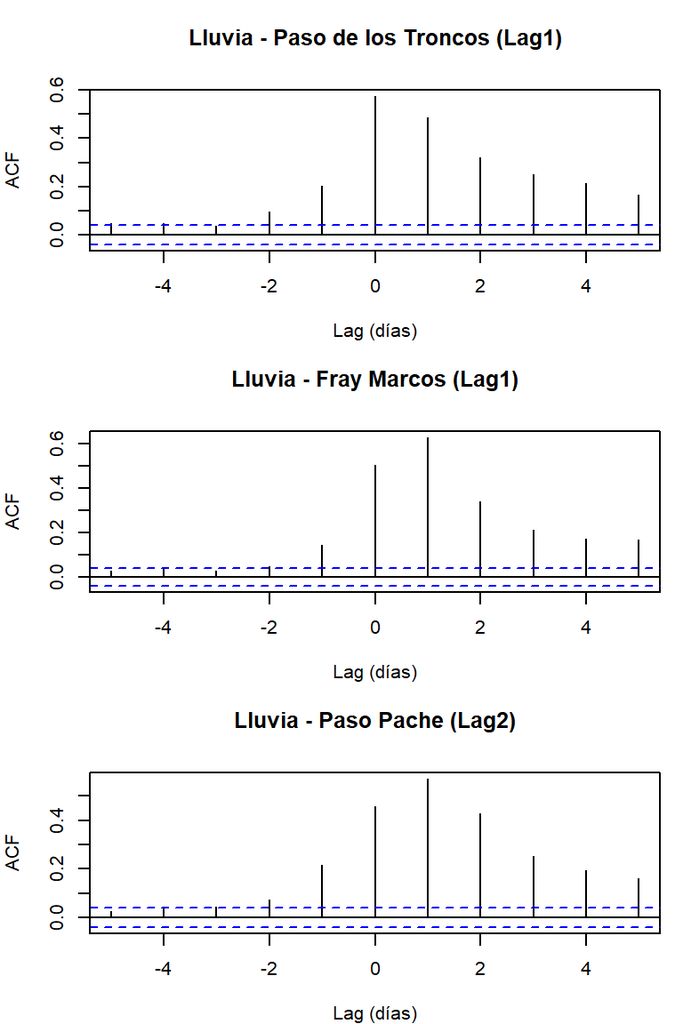

```r
obs.data$q23_lag1 = lag(obs.data$q23)
obs.data$q36_lag1 = lag(obs.data$q36)
obs.data$q41_lag2 = lag(lag(obs.data$q41))

#obs.data = data.frame(obs.data)
#obs.data$q23_lag1 = c(obs.data$q23[2:nrow(obs.data)],NA)
#obs.data$q36_lag1 = c(obs.data$q36[2:nrow(obs.data)],NA)
#obs.data$q41_lag2 = c(obs.data$q41[3:nrow(obs.data)],NA,NA)



par(mfrow=c(3,1), mar=c(4,4,4,1))
ccf(as.vector(obs.data$q23_lag1),
    p,
    na.action=na.pass, lag.max=5,
    main = "Lluvia - Paso de los Troncos (Lag1)",
    xlab= "Lag (días)")

ccf(as.vector(obs.data$q36_lag1),
    p,
    na.action=na.pass, lag.max=5,
    main="Lluvia - Fray Marcos (Lag1)",
    xlab= "Lag (días)")

ccf(as.vector(obs.data$q41_lag2),
    p,
    na.action=na.pass, lag.max=5,
    main="Lluvia - Paso Pache (Lag2)",
    xlab= "Lag (días)")
```

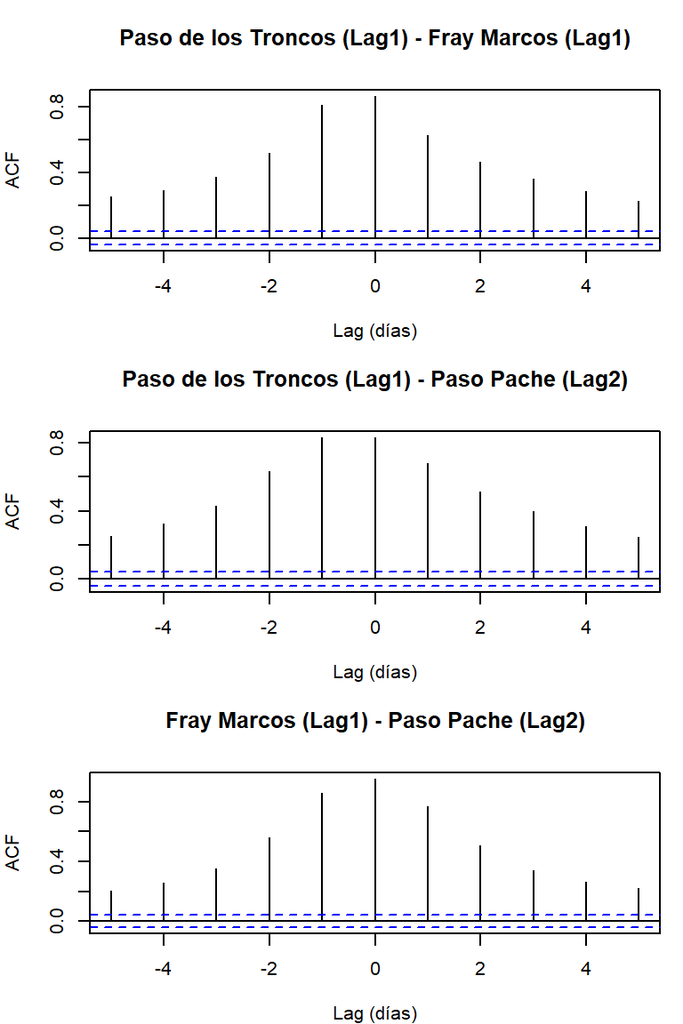

```r
par(mfrow=c(3,1), mar=c(4,4,4,1))
ccf(obs.data$q23_lag1,
    obs.data$q36_lag1,
    na.action=na.pass, lag.max=5,
    main = "Paso de los Troncos (Lag1) - Fray Marcos (Lag1)",
    xlab= "Lag (días)")

ccf(obs.data$q23_lag1,
    obs.data$q41_lag2,
    na.action=na.pass, lag.max=5,
    main="Paso de los Troncos (Lag1) - Paso Pache (Lag2)",
    xlab= "Lag (días)")

ccf(obs.data$q36_lag1,
    obs.data$q41_lag2,
    na.action=na.pass, lag.max=5,
    main="Fray Marcos (Lag1) - Paso Pache (Lag2)",
    xlab= "Lag (días)")
```

A work by [Rafael Navas](https://github.com/)